# stats_review

```python
import pandas as pd
import numpy as np

import matplotlib.pyplot as plt
%matplotlib inline
import seaborn as sns

from math import sqrt
from scipy import stats

np.random.seed(123)

from pydataset import data

from env import host, user, password

from wrangle_telco import wrangle_telco
from explore import correlation_exploration
```

## Statistical Distributions - Quick Look

**Uniform Distribution -** allows us to model events where the outcome is discrete, and each outcome has an equally likely chance of occurring.

**What You Need**

Finite number of outcomes equally likely to happen.

**So what?**

Allows you to construct a random variable that has an equal opportunity of being any one of the integers in the range you establish using the start (inclusive) and stop (exclusive) below.

**Now What?**

`stats.randint(start, stop)`

**Binomial Distribution -** allows us to model the number of successes after a number of trials, given a certain probability of success. This distribution assumes that each trial is independent. Discrete, upper bound by # of events

**What You Need**

n = trials

p = p(success)

**So what?**

returns the likelihood of successes

**Now What?**

`stats.binom(n, p)`

**Normal Distribution -** allows us to model a continuous random variable where the further away from the mean you are, the less likely the outcome.

**What You Need**

mean

standard deviation

**So what?**

The Standard Normal Distribution is a normal distribution with a mean of 0 and a standard deviation of 1.

**Now What?**

`stats.norm(mean, standard deviation)`

**Poisson Distribution -** allows us to model a situation where a certain number of events happen over a specified time interval. This distribution assumes that the events are independent of each other. Continuous, not upper bound. Can go off into $\infty$

**What You Need**

average rate

**So what?**

Returns the number of events that can be classified as successes or failures.

**Now What?**

`stats.poisson(average rate)`

**PDF** (Probability Density Function) / **PMF** (Probability Mass Function) - The probability that your random variable takes on an **EXACT** value.

`distribution.pdf(probability/continuous)`

`distribution.pmf(value/discrete)`

**CDF** (Cumulative Density Function) / **PPF** (Percent Point Function) - The probability that your random variable takes on a value **less than or equal to** a given point.

`distribution.cdf(value/discrete)`

`distribution.ppf(probability/continuous)`

**SF** (Survival Function) / **ISF** (Inverse Survival Function) - The probability that your random variable takes on a value **greater than** a given point.

`distribution.sf(value/discrete)`

`distribution.isf(probability/continuous)`

## The Central Limit Theorem - Proof of Concept

**What's so important about The Central Limit Theorem?**

- If we repeatedly take random samples of the same size from a the same population, and compute the sample mean for each of the samples, the sampling distribution of the sample means will be a normal distribution no matter what the initial distribution of the population was.
- Even if our original population has a skewed distribution, our sampling distribution will be normal if we have a large enough sample!

**So what?!**

- In hypothesis testing, the assumption is that our data is from a normal distribution. In real life, our data is usually **NOT** normally distributed! (Think of the salaries in the Employees database or the home values in the Zillow database.)

**Now What?**

- The Central Limit Theorem and an appropriate sample size allow us to get around the problems of skewed, real-world data distributions, assume our sample data is normally distributed, and run our hypotheses tests.

```python
n_dice_per_experiment = ncols = 10
n_experiments = nrows = 100
```

```python
# Create 2-d array of random numbers between 1 and 6 to represent ten dice rolls for each column

dataset = np.random.randint(1, 7, (nrows, ncols))

dataset[:4]
```

```
array([[6, 3, 5, 3, 2, 4, 3, 4, 2, 2],
       [1, 2, 2, 1, 1, 2, 4, 6, 5, 1],
       [1, 5, 2, 4, 3, 5, 3, 5, 1, 6],
       [1, 2, 4, 5, 5, 5, 2, 6, 4, 3]])
```

```python
# Calculate the average for each set of 10 dice rolls

calculated_averages = dataset.mean(axis=1)
calculated_averages
```

```
array([3.4, 2.5, 3.5, 3.7, 3.2, 4.7, 3.4, 3.2, 3.4, 3. , 3.7, 3.5, 4. ,
       4.5, 2.9, 2.8, 2.9, 3.8, 3.2, 3.6, 3.4, 4. , 3.5, 3.3, 3.6, 3. ,
       4.3, 3. , 3.3, 3.2, 4.2, 3.9, 3.2, 3.8, 3.6, 3.4, 2.7, 3.4, 3.2,
       3.1, 3.2, 3. , 4.1, 3.3, 3. , 4.1, 3.4, 3.3, 2.9, 3.8, 3.4, 3.6,
       3.9, 3.2, 4.7, 3.8, 3.5, 2.8, 3.8, 4.7, 4.1, 3.5, 2.8, 3.7, 3.4,
       3.7, 3.6, 4.1, 3.6, 3.5, 2.9, 4. , 3.2, 3.4, 4.4, 2.9, 3.2, 3.9,
       1.9, 3. , 3. , 3.5, 3.3, 4.4, 3.4, 4.2, 4.1, 3.2, 3.5, 3.5, 3.8,
       3.1, 3.6, 2.9, 2.9, 4. , 3.3, 3.1, 3.4, 3.6])
```

```python
# Visualize the distribution of 100 observations of 10 dice rolls

plt.hist(calculated_averages)
plt.xlabel(f'Average of {n_dice_per_experiment} dice rolls')
plt.ylabel('# of Occurances')
plt.title(f'Outcome of averaging {n_dice_per_experiment} dice rolls {n_experiments} times')
plt.show()
```

[figure not shown]

## Hypothesis Testing - Overview

**What is Hypothesis Testing?**

- We use hypothesis tests to draw conclusions, answer questions, or interpret beliefs we have about a population using sample data.
- A hypothesis test evaluates two mutually exclusive statements about a population and informs us which statement is best supported by our sample data.

  > $H_0$: There is no difference between smokers' tips and the overall population's tip average.

  > $H_a$: There is a difference between smokers' tips and the overall population's tip average.

**So what?!**

- There are two possible outcomes; if the result confirms the hypothesis, then you've made a measurement. If the result is contrary to the hypothesis, then you've made a discovery - Enrico Fermi

**Now What?**

> 1. Set up a hypothesis.
> 2. Calculate a test statistic.
> 3. Find a p-value from the test statistic.
> 4. Reject or fail to reject your Null hypothesis

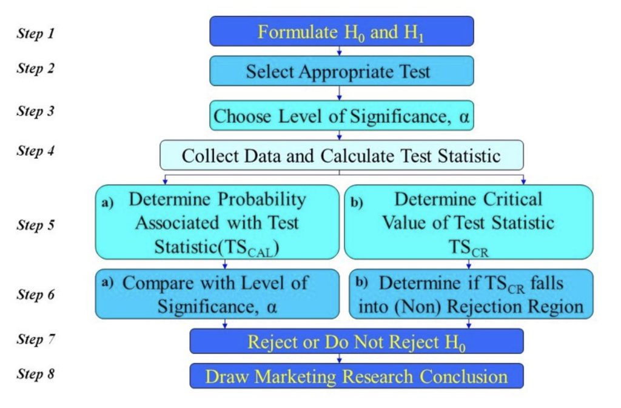

### Hypothesis Testing Errors

**What is a Type I Error == False Positive?**

- We predict there is a difference when in reality there is no difference
- We reject the Null hypothesis when the Null hypothesis is actually True

**So What?**

- If we are trying to determine whether a customer will churn, and our **model predicts that they will churn (positive for churn)**, but **they do not end up churning (False prediction)**, this is a **False Positive**. We have wasted time and money trying to woo a customer who was not going to leave us.

**What is a Type II Error == False Negative?**

- We predict that there is no difference when in reality there is a difference.
- We fail to reject the Null hypothesis when the Null hypothesis is actually false.

**So What?**

- If we are trying to determine whether a customer will churn, and our **model predicts that they will not churn (negative for churn)**, but **they end up churning (False Prediction)**, this is a **False Negative**. We lost the opportunity to woo a customer that was going to leave us before they left.

**Now What?**

- If we have a classification model that predicts customer churn, we can decide how to balance our Type I and Type II Errors to have a model that suits our needs.

**In the instance of churn, which type of error would be more costly to the Telco company?**

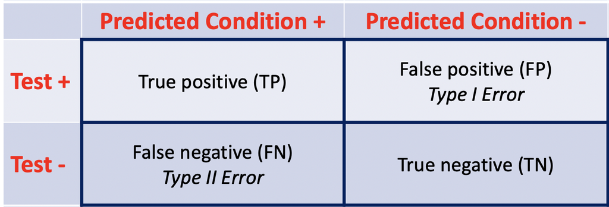

## T-Test - Continuous v Categorical Variables

**What is a T-Test?**

- A type of inferential statistic used to determine if there is a significant difference between the means of two groups which may be related in certain features.
- It compares a categorical and a continuous variable by comparing the mean of the continuous variable by subgroups or the mean of a subgroup to the mean of the population.

**So What?**

We can ask questions like:

- **One Sample T-test** is when we compare the mean for a subgroup to the population mean.

  > Are sales for group A higher when we run a promotion?
- **Two Sample T-test** is when we compare the mean of one subgroup to the mean of another subgroup.

  > Do customers who receive a promotion spend more money than those who don't?

**Now What?**

- If your p-value is higher than your $a$, you fail to reject your Null Hypothesis.
- If your p-value is lower than your $a$, you reject your Null Hypothesis.

> Types of T-Tests
- **one-tailed test** looks for a specific difference: appropriate if you only want to determine if there is a difference between groups in a specific direction, positive only or negative only.
- **two-tailed test** looks for any difference: appropriate if you want to test for the possibility of both positive or negative differences.

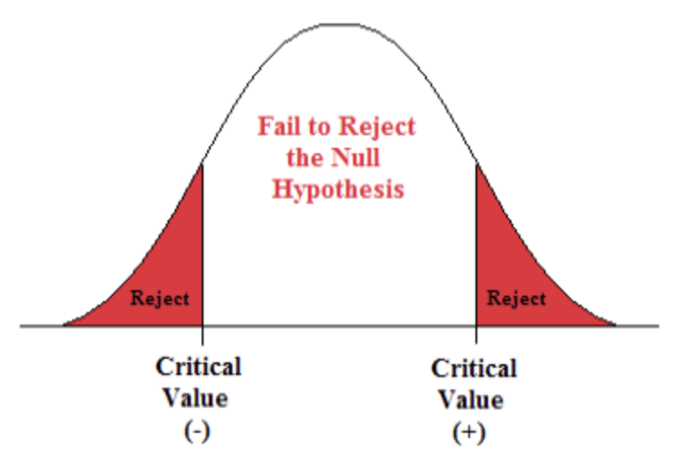

- **one-sample t-test** compares the mean of a subgroup with the population mean.

`scipy.stats.ttest_1samp(a, popmean)`

a = array, list, Series

popmean = single value

- **two-sample t-test** compares the means of two subgroups.

`scipy.stats.ttest_ind(a, b)`

a = array, list, Series

b = array, list, Series

> **Important Terms**
- **a confidence level** is the probability that if a poll/test/survey were repeated over and over again, the results obtained would be the same. It conveys how confident we are in our results. Raising your confidence level lowers your chances of Type I Errors, or False Positives. (Common examples might be 90%, 95%, or 99%)
- **alpha** --> $a$ = 1 - confidence level. If your p-value is less than your $a$, which you set before you begin your test, then your test findings are significant. If it is close, it is at your discretion. Your results still may be significant even though slightly above your chosen cutoff. Also, alpha is the maximum probability that you have a Type I Error.

> For a 95% confidence level, the value of alpha is .05 which means there is a 5% probability that you will reject a True Null hypothesis or have a False Positive.
- **t-statistic** is simply the calculated difference represented in units of standard error. The greater the magnitude of t, the greater the evidence against the null hypothesis. Why does it matter? **Short Answer:** It allows us to calculate our p-value!
- **p-values** are values we obtain from hypothesis testing. They represent the probability that our obtained result is due to chance given that our stated hypothesis is true.
- Looking for more information? I found this article useful.

https://towardsdatascience.com/everything-you-need-to-know-about-hypothesis-testing-part-i-4de9abebbc8a

```python
df = data('tips')
```

```python
df.head()
```

|  | total_bill | tip | sex | smoker | day | time | size |
| --- | --- | --- | --- | --- | --- | --- | --- |
| 1 | 16.99 | 1.01 | Female | No | Sun | Dinner | 2 |
| 2 | 10.34 | 1.66 | Male | No | Sun | Dinner | 3 |
| 3 | 21.01 | 3.50 | Male | No | Sun | Dinner | 3 |
| 4 | 23.68 | 3.31 | Male | No | Sun | Dinner | 2 |
| 5 | 24.59 | 3.61 | Female | No | Sun | Dinner | 4 |

```python
# T-tests assume that the continous variable is normally distributed,
# so we need to do a quick check of this.

sns.distplot(df.tip)
plt.title('Distribution of Tips - Right Skewed')
plt.show()
```

[figure not shown]

### Compare mean and median of df.tip

- **The distribution is right-skewed, so we see below the mean is slightly higher than the median.**

```python
print(f'The mean is: {df.tip.mean()}, and the median is {df.tip.median()}')
print('This is close enough to normal to continue.')
```

```
The mean is: 2.9982786885245902, and the median is 2.9
This is close enough to normal to continue.
```

### Calculate the t-statistic and p-value for a One Sample T-Test by hand

> $H_0$: There is no difference between smokers' tips and the overall population's tip average.

> $H_a$: There is a difference between smokers' tips and the overall population's tip average.

```python
confidence_interval = .95
alpha = round(1 - confidence_interval, 2)
print(f'alpha = {alpha}')
```

```
alpha = 0.05
```

```python
smokers = df[df.smoker == 'Yes']
```

```python
pop_mean = df.tip.mean()
```

```python
xbar = smokers.tip.mean()
```

```python
smokers_standard_dev = smokers.tip.std()
```

```python
n = smokers.shape[0]
```

```python
degrees_freedom = n - 1
```

```python
standard_error = smokers_standard_dev / sqrt(n)
```

```python
t = (xbar - pop_mean) / (smokers_standard_dev / sqrt(n))
```

```python
print(f"Our t-statistic for smokers' tips is {t}.")
```

```
Our t-statistic for smokers' tips is 0.07177676877620093.
```

```python
p = stats.t(degrees_freedom).sf(t) * 2
```

```python
print(f"Our p-value for smokers' tips is {p}")
print(f'This means there is about a {round(p * 100,2)}% chance that we observe the data we have.')
```

```
Our p-value for smokers' tips is 0.9429353685499238
This means there is about a 94.29% chance that we observe the data we have.
```

```python
print(f't = {t:.3f}')
print(f'p = {p:.3f}')
```

```
t = 0.072
p = 0.943
```

```python
print(f'Our p-value is less than our alpha: {p < alpha}')
```

```
Our p-value is less than our alpha: False
```

- **We fail to reject the Null hypothesis that there is no difference in the average tip of smokers and the general population.**

### Calculate the t-statistic and p-value using scipy.stats module

```python
t, p = stats.ttest_1samp(smokers.tip, df.tip.mean())

print(f't = {t:.3f}')
print(f'p = {p:.3f}')
```

```
t = 0.072
p = 0.943
```

```python
print(f'Our p-value is less than our alpha: {p < alpha}')
```

```
Our p-value is less than our alpha: False
```

- **Now THAT is awesome!!!!**

### Calculate the t-statistic and p-value for a Two Sample T-Test by hand

> $H_0$: There is no difference between women's and men's tips.

> $H_a$: There is a difference between women's and men's tips.

```python
confidence_interval = .95
alpha = round(1 - confidence_interval, 2)
print(f'alpha = {alpha}')
```

```
alpha = 0.05
```

```python
males = df[df.sex == 'Male']
females = df[df.sex == 'Female']
```

```python
males_xbar = males.tip.mean()
females_xbar = females.tip.mean()
```

```python
males_xbar
```

```
3.0896178343949052
```

```python
females_xbar
```

```
2.833448275862069
```

```python
n_males = males.shape[0]
n_females = females.shape[0]
print(f'There are {n_males} males in data.')
print(f'There are {n_females} females in our data.')
```

```
There are 157 males in data.
There are 87 females in our data.
```

```python
std_males = males.tip.std()
std_females = females.tip.std()
```

```python
degrees_freedom = n_males + n_females - 2
```

```python
s_p = sqrt(((n_males - 1) * std_males**2 + (n_females - 1) * std_females ** 2) / (n_males + n_females - 2))
```

```python
standard_error = sqrt(std_males ** 2 / n_males + std_females ** 2 / n_females)
standard_error
```

```
0.17197939068320425
```

```python
t = (males_xbar - females_xbar) / (s_p * sqrt(1/n_males + 1/n_females))
print(f'The t-statistic for the two sample t-test comparing male to female tips is {round(t,3)}.')
```

```
The t-statistic for the two sample t-test comparing male to female tips is 1.388.
```

```python
p = stats.t(degrees_freedom).sf(t) * 2
print(f'Our p-value is {round(p, 3)}.')
print(f'This means there is about a {round(p * 100, 2)}% chance that we observe the data we have.')
```

```
Our p-value is 0.166.
This means there is about a 16.65% chance that we observe the data we have.
```

```python
print(f'Our p-value is less than our alpha: {p < alpha}')
```

```
Our p-value is less than our alpha: False
```

- **We fail to reject the Null hypothesis that there is no difference in the average tip of women and men. BUT, this is still a low-ish p-value. There could be something here?**

### Again, using scipy.stats.ttest_ind()

```python
t, p = stats.ttest_ind(males.tip, females.tip)
```

```python
print(f'The t-statistic for the two sample t-test comparing male to female tips is {round(t,3)}.')
```

```
The t-statistic for the two sample t-test comparing male to female tips is 1.388.
```

```python
print(f'Our p-value is {round(p, 3)}.')
print(f'This means there is about a {round(p * 100, 2)}% chance that we observe the data we have.')
```

```
Our p-value is 0.166.
This means there is about a 16.65% chance that we observe the data we have.
```

```python
print(f'Our p-value is less than our alpha: {p < alpha}')
```

```
Our p-value is less than our alpha: False
```

### T-Test Exercises

#### Use the mpg data set

```python
mpg = data('mpg')
```

```python
mpg.head()
```

|  | manufacturer | model | displ | year | cyl | trans | drv | cty | hwy | fl | class |
| --- | --- | --- | --- | --- | --- | --- | --- | --- | --- | --- | --- |
| 1 | audi | a4 | 1.8 | 1999 | 4 | auto(l5) | f | 18 | 29 | p | compact |
| 2 | audi | a4 | 1.8 | 1999 | 4 | manual(m5) | f | 21 | 29 | p | compact |
| 3 | audi | a4 | 2.0 | 2008 | 4 | manual(m6) | f | 20 | 31 | p | compact |
| 4 | audi | a4 | 2.0 | 2008 | 4 | auto(av) | f | 21 | 30 | p | compact |
| 5 | audi | a4 | 2.8 | 1999 | 6 | auto(l5) | f | 16 | 26 | p | compact |

```python
mpg.info()
```

```
<class 'pandas.core.frame.DataFrame'>
Int64Index: 234 entries, 1 to 234
Data columns (total 11 columns):
 #   Column        Non-Null Count  Dtype
---  ------        --------------  -----
 0   manufacturer  234 non-null    object
 1   model         234 non-null    object
 2   displ         234 non-null    float64
 3   year          234 non-null    int64
 4   cyl           234 non-null    int64
 5   trans         234 non-null    object
 6   drv           234 non-null    object
 7   cty           234 non-null    int64
 8   hwy           234 non-null    int64
 9   fl            234 non-null    object
 10  class         234 non-null    object
dtypes: float64(1), int64(4), object(6)
memory usage: 21.9+ KB
```

#### Is there a difference in fuel efficiency in cars from 2008 vs 1999?

> $H_0$: There is no difference between the fuel efficiency in cars from 2008 and 1999.

> $H_a$: There is a difference between the fuel efficiency in cars from 2008 and 1999.

```python
mpg['avg_mileage'] = (mpg['cty'] + mpg['hwy']) / 2
```

```python
mpg.head(1)
```

|  | manufacturer | model | displ | year | cyl | trans | drv | cty | hwy | fl | class | avg_mileage |
| --- | --- | --- | --- | --- | --- | --- | --- | --- | --- | --- | --- | --- |
| 1 | audi | a4 | 1.8 | 1999 | 4 | auto(l5) | f | 18 | 29 | p | compact | 23.5 |

```python
cars99 = mpg[mpg.year == 1999].avg_mileage
cars99.head()
```

```
1    23.5
2    25.0
5    21.0
6    22.0
8    22.0
Name: avg_mileage, dtype: float64
```

```python
cars08 = mpg[mpg.year == 2008].avg_mileage
cars08.head()
```

```
3     25.5
4     25.5
7     22.5
10    24.0
11    23.0
Name: avg_mileage, dtype: float64
```

```python
# Comparison of distribution of average mileage of my two subgroups

plt.hist([cars99, cars08], label=["1999 cars", "2008 cars"])
plt.legend(loc="upper right")
plt.title("Average Mileage Comparison - 1999 and 2008 Cars")

plt.show()
```

[figure not shown]

```python
t, p = stats.ttest_ind(cars99, cars08)
print('t-statistic: ', t)
print('p_value: ', p)
```

```
t-statistic:  0.21960177245940962
p_value:  0.8263744040323578
```

```python
print(f'Our p-value is less than our alpha: {p < alpha}')
```

```
Our p-value is less than our alpha: False
```

- **We fail to reject the Null hypothesis. Our high .83 p-value tells us that there is not a significant difference in the fuel efficiency between the two subgroups, vehicles from 1999 and vehicles from 2008.**

#### Are compact cars more fuel-efficient than the average car?

> $H_0$: There is no difference between the fuel efficiency of compact cars and the average car.

> $H_a$: There is a difference between the fuel efficiency of compact cars and the average car.

```python
compact = mpg[mpg['class'] == 'compact'].avg_mileage
compact.head()
```

```
1    23.5
2    25.0
3    25.5
4    25.5
5    21.0
Name: avg_mileage, dtype: float64
```

```python
# What is the mean of avg_mileage for compact cars?

compact.mean()
```

```
24.21276595744681
```

```python
all_cars_mean = mpg.avg_mileage.mean()
all_cars_mean
```

```
20.14957264957265
```

```python
t, p = stats.ttest_1samp(compact, all_cars_mean)
print(f't-statistic: {round(t, 3)} and p-value is: {round(p,3)}.')
```

```
t-statistic: 7.897 and p-value is: 0.0.
```

```python
print(f'Our p-value is less than our alpha: {p < alpha}')
```

```
Our p-value is less than our alpha: True
```

- **We reject the Null hypothesis. There is a difference in the fuel efficiency of compact cars and the average car.**

#### Do manual cars get better gas mileage than automatic cars?

> $H_0$: There is no difference between the fuel efficiency of manual and automatic cars.

> $H_a$: There is a difference between the fuel efficiency of manual and automatic cars.

```python
auto = mpg[mpg.trans.str.startswith('auto')]
auto.head(1)
```

|  | manufacturer | model | displ | year | cyl | trans | drv | cty | hwy | fl | class | avg_mileage |
| --- | --- | --- | --- | --- | --- | --- | --- | --- | --- | --- | --- | --- |
| 1 | audi | a4 | 1.8 | 1999 | 4 | auto(l5) | f | 18 | 29 | p | compact | 23.5 |

```python
manual = mpg[mpg.trans.str.startswith('man')]
manual.head(1)
```

|  | manufacturer | model | displ | year | cyl | trans | drv | cty | hwy | fl | class | avg_mileage |
| --- | --- | --- | --- | --- | --- | --- | --- | --- | --- | --- | --- | --- |
| 2 | audi | a4 | 1.8 | 1999 | 4 | manual(m5) | f | 21 | 29 | p | compact | 25.0 |

```python
t, p = stats.ttest_ind(auto.avg_mileage, manual.avg_mileage )
```

```python
print(f't-statistic: {round(t, 3)} and p-value is: {round(p,3)}.')
```

```
t-statistic: -4.593 and p-value is: 0.0.
```

```python
print(f'Our p-value is less than our alpha: {p < alpha}')
```

```
Our p-value is less than our alpha: True
```

- **We reject the Null hypothesis. There is a difference in the fuel efficiency of a manual or automatic transmission car.**

## Correlation - Continuous v Continuous Variables

**What is a correlation test?**

- Correlation is a statistical measure that describes how two variables are related and indicates that as one variable changes in value, the other variable tends to change in a specific direction.

> **Positive Correlation:** both variables change in the same direction.

> **Neutral Correlation:** No relationship in the change of the variables.

> **Negative Correlation:** variables change in opposite directions.

**So What?**

- Some machine learning algorithms, such as Linear Regressions, may not perform as well when there is multicolinearity or independent variables that are correlated.

**Now What?**

- Calculate the Pearson correlation coefficient, r.

> The Pearson correlation coefficient, r, is a unitless, continuous numerical measure between -1 and 1, where 1 = perfect positive correlation and -1 = perfect negative correlation. It can be used to summarize the strength of the linear relationship between two data samples.

> The bigger the value of a correlation coefficient, the less likely it is to have occurred merely by chance, and the more likely it is that it has occurred because it represents a genuine relationship between the two variables in question.
- Calculate the coresponding t-values.
- Test whether the t-values are significant or not, p-value.
- We can use `r, p = stats.pearsonr(x,y)` to find r and p-values
- **Keep in mind that...**
- Correlation doesn't mean that one variable is causing the change in another variable!
- Pearson's correlation tests measure the linear relationship between 2 variables and not other types of relationships. (There are other correlation tests, like Spearman's correlation, that test for non-linear relationships.)
- Correlations can be misleading when confounding variables are ignored. There may be a third variable influencing the other two variables in your correlation test. (An increase in ice cream sales causes an increase in murder rate.)

### Let's do a quick test and then go through the exercises...

> $H_0$: There is no linear relationship between average mileage and cylinders of a vehicle.

> $H_a$: There is a linear relationship between average mileage and cylinders of a vehicle.

**In case you want to see the guts of my function correlation_exploration**

```
def correlation_exploration(df, x_string, y_string):
    '''
    This nifty function takes in a df, a string for x variable,
    and a string for y variable and displays their correlation.
    '''
    r, p = stats.pearsonr(df[x_string], df[y_string])
    df.plot.scatter(x_string, y_string)
    plt.title(f"{x_string}'s Relationship with {y_string}")
    print(f'The p-value is: {p}. There is {round(p,3)}% chance that we see these results by chance.')
    print(f'r = {round(r, 2)}')
    plt.show()
```

```python
correlation_exploration(mpg, 'avg_mileage', 'cyl')
```

```
The p-value is: 6.387070246026389e-51. There is 0.0% chance that we see these results by chance.
r = -0.79
```

[figure not shown]

### Correlation Exercises

**In case you want to see the guts of my wrangle_telco function**

```
def wrangle_telco():
    """
    Queries the telco_churn database
    Returns a clean df with six columns:
    customer_id(object), monthly_charges(float),
    tenure(int), total_charges(float),
    phone_service(object), internet_service_type_id(int)
    """
    df = get_data_from_sql()
    df.tenure.replace(0, 1, inplace=True)
    df.total_charges.replace(' ', df.monthly_charges, inplace=True)
    df.total_charges = df.total_charges.astype(float)
    return df
```

```python
telco = wrangle_telco()
```

```python
telco.info()
```

```
<class 'pandas.core.frame.DataFrame'>
RangeIndex: 7043 entries, 0 to 7042
Data columns (total 6 columns):
 #   Column                    Non-Null Count  Dtype
---  ------                    --------------  -----
 0   customer_id               7043 non-null   object
 1   monthly_charges           7043 non-null   float64
 2   tenure                    7043 non-null   int64
 3   total_charges             7043 non-null   float64
 4   phone_service             7043 non-null   object
 5   internet_service_type_id  7043 non-null   int64
dtypes: float64(2), int64(2), object(2)
memory usage: 330.3+ KB
```

```python
telco.head()
```

|  | customer_id | monthly_charges | tenure | total_charges | phone_service | internet_service_type_id |
| --- | --- | --- | --- | --- | --- | --- |
| 0 | 0002-ORFBO | 65.6 | 9 | 593.30 | Yes | 1 |
| 1 | 0003-MKNFE | 59.9 | 9 | 542.40 | Yes | 1 |
| 2 | 0004-TLHLJ | 73.9 | 4 | 280.85 | Yes | 2 |
| 3 | 0011-IGKFF | 98.0 | 13 | 1237.85 | Yes | 2 |
| 4 | 0013-EXCHZ | 83.9 | 3 | 267.40 | Yes | 2 |

#### Use the telco_churn data. Does tenure correlate with monthly charges? Total charges? What happens if you control for phone and internet service?

> $H_0$: There is no correlation between tenure and monthly_charges.

> $H_a$: There is a correlation between tenure and monthly_charges.

```python
correlation_exploration(telco, 'tenure', 'monthly_charges')
```

```
The p-value is: 4.320450791022193e-99. There is 0.0% chance that we see these results by chance.
r = 0.25
```

[figure not shown]

**Based on our r and p-value, we reject the Null hypothesis. Our r informs us that there is a small positive correlation between tenure and monthly_charges, and our p-value informs us that the finding is significant. We can see from the low r value that the correlation, though significant, is not strong.**

> $H_0$: There is no correlation between tenure and total_charges.

> $H_a$: There is a correlation between tenure and total_charges.

```python
correlation_exploration(telco, 'tenure', 'total_charges')
```

```
The p-value is: 0.0. There is 0.0% chance that we see these results by chance.
r = 0.83
```

[figure not shown]

**Based on our r and p-value, we reject the Null hypothesis. There is a strong correlation, r = 0.83, between tenure and total_charges. This is not surprising because total charges necessarily add up the longer a customer remain with the company, tenure. Our p-value of 0 informs us that the finding is significant.**

```python
# Create a subset of customers without phone service but with internet.
# This ONLY includes DSL as we find that Fiber customers ALL have phone service.

no_phone_yes_dsl = telco[(telco.phone_service == 'No') & ((telco.internet_service_type_id == 1) | (telco.internet_service_type_id == 2))]
no_phone_yes_dsl
```

|  | customer_id | monthly_charges | tenure | total_charges | phone_service | internet_service_type_id |
| --- | --- | --- | --- | --- | --- | --- |
| 10 | 0017-DINOC | 45.20 | 54 | 2460.55 | No | 1 |
| 14 | 0019-GFNTW | 45.05 | 56 | 2560.10 | No | 1 |
| 16 | 0020-JDNXP | 61.25 | 34 | 1993.20 | No | 1 |
| 19 | 0023-HGHWL | 25.10 | 1 | 25.10 | No | 1 |
| 25 | 0032-PGELS | 30.50 | 1 | 30.50 | No | 1 |
| ... | ... | ... | ... | ... | ... | ... |
| 6979 | 9906-NHHVC | 53.50 | 65 | 3517.90 | No | 1 |
| 6980 | 9907-SWKKF | 25.05 | 1 | 25.05 | No | 1 |
| 6996 | 9928-BZVLZ | 49.85 | 12 | 552.10 | No | 1 |
| 7016 | 9955-QOPOY | 60.80 | 69 | 4263.40 | No | 1 |
| 7042 | 9995-HOTOH | 59.00 | 63 | 3707.60 | No | 1 |

682 rows × 6 columns

```python
# The relationship between tenure and monthly charges for customers that don't have phone service
# but DO have DSL

correlation_exploration(no_phone_yes_dsl, 'tenure', 'monthly_charges')
```

```
The p-value is: 4.022392937551241e-64. There is 0.0% chance that we see these results by chance.
r = 0.59
```

[figure not shown]

**We reject the Null hypothesis that there is no correlation between tenure and monthly charges based on our p-value being below our alpha of 0.05 and our r of 0.59**

```python
# The relationship between tenure and total charges for customers that don't have phone service
# but DO have DSL

correlation_exploration(no_phone_yes_dsl, 'tenure', 'total_charges')
```

```
The p-value is: 0.0. There is 0.0% chance that we see these results by chance.
r = 0.95
```

[figure not shown]

**We reject the Null hypothesis that there is no correlation between tenure and total charges based on our p-value being below our alpha of 0.05 and our r of 0.95. There is a strong positive correlation between tenure and total charges for customer with DSL and no phone service.**

```python
# Create subset of customers who have Fiber... all Fiber customers also have phone service

yes_phone_yes_fiber = telco[telco.internet_service_type_id == 2]
yes_phone_yes_fiber.head()
```

|  | customer_id | monthly_charges | tenure | total_charges | phone_service | internet_service_type_id |
| --- | --- | --- | --- | --- | --- | --- |
| 2 | 0004-TLHLJ | 73.90 | 4 | 280.85 | Yes | 2 |
| 3 | 0011-IGKFF | 98.00 | 13 | 1237.85 | Yes | 2 |
| 4 | 0013-EXCHZ | 83.90 | 3 | 267.40 | Yes | 2 |
| 6 | 0013-SMEOE | 109.70 | 71 | 7904.25 | Yes | 2 |
| 7 | 0014-BMAQU | 84.65 | 63 | 5377.80 | Yes | 2 |

> $H_0$: There is no correlation between tenure and monthly_charges for customers with phone and Fiber services.

> $H_a$: There is a correlation between tenure and monthly_charges for customers with phone and Fiber services.

```python
# the correlation of tenure and monthly charges for customers who have phone and Fiber service

correlation_exploration(yes_phone_yes_fiber, 'tenure', 'monthly_charges')
```

```
The p-value is: 0.0. There is 0.0% chance that we see these results by chance.
r = 0.62
```

[figure not shown]

**We reject the Null hypothesis that there is no correlation between tenure and montlhy charges based on our p-value being below our alpha of 0.05 and our r of 0.62. There is a positive correlation between tenure and monthly charges for customers with Fiber and phone service.**

> $H_0$: There is no correlation between tenure and total_charges for customers with phone and Fiber services.

> $H_a$: There is a correlation between tenure and total_charges for customers with phone and Fiber services.

```python
# the correlation of tenure and total charges for customers who have phone and Fiber service

correlation_exploration(yes_phone_yes_fiber, 'tenure', 'total_charges')
```

```
The p-value is: 0.0. There is 0.0% chance that we see these results by chance.
r = 0.99
```

[figure not shown]

**We reject the Null hypothesis that there is no correlation between tenure and total charges based on our p-value being below our alpha of 0.05 and our r of 0.99. There is an almost perfect positive correlation between tenure and total charges for customers with Fiber and phone service.**

#### Use the sleepstudy data. Is there a relationship between days and reaction time?

> $H_0$: There is no correlation between the number of days a subject is in a study and their reaction time.

> $H_a$: There is a correlation between the number of days a subject is in a study and their reaction time.

```python
data('sleepstudy', show_doc=True)
```

```
sleepstudy

PyDataset Documentation (adopted from R Documentation. The displayed examples are in R)

## Reaction times in a sleep deprivation study

### Description

The average reaction time per day for subjects in a sleep deprivation study.
On day 0 the subjects had their normal amount of sleep. Starting that night
they were restricted to 3 hours of sleep per night. The observations represent
the average reaction time on a series of tests given each day to each subject.

### Format

A data frame with 180 observations on the following 3 variables.

`Reaction`

Average reaction time (ms)

`Days`

Number of days of sleep deprivation

`Subject`

Subject number on which the observation was made.

### Details

These data are from the study described in Belenky et al. (2003), for the
sleep-deprived group and for the first 10 days of the study, up to the
recovery period.

### References

Gregory Belenky, Nancy J. Wesensten, David R. Thorne, Maria L. Thomas, Helen
C. Sing, Daniel P. Redmond, Michael B. Russo and Thomas J. Balkin (2003)
Patterns of performance degradation and restoration during sleep restriction
and subsequent recovery: a sleep dose-response study. _Journal of Sleep
Research_ **12**, 1–12.

### Examples

    str(sleepstudy)
    require(lattice)
    xyplot(Reaction ~ Days | Subject, sleepstudy, type = c("g","p","r"),
           index = function(x,y) coef(lm(y ~ x))[1],
           xlab = "Days of sleep deprivation",
           ylab = "Average reaction time (ms)", aspect = "xy")
    (fm1 <- lmer(Reaction ~ Days + (Days|Subject), sleepstudy))
    (fm2 <- lmer(Reaction ~ Days + (1|Subject) + (0+Days|Subject), sleepstudy))
```

```python
sleep = data('sleepstudy')
sleep.head()
```

|  | Reaction | Days | Subject |
| --- | --- | --- | --- |
| 1 | 249.5600 | 0 | 308 |
| 2 | 258.7047 | 1 | 308 |
| 3 | 250.8006 | 2 | 308 |
| 4 | 321.4398 | 3 | 308 |
| 5 | 356.8519 | 4 | 308 |

```python
sleep.info()
```

```
<class 'pandas.core.frame.DataFrame'>
Int64Index: 180 entries, 1 to 180
Data columns (total 3 columns):
 #   Column    Non-Null Count  Dtype
---  ------    --------------  -----
 0   Reaction  180 non-null    float64
 1   Days      180 non-null    int64
 2   Subject   180 non-null    int64
dtypes: float64(1), int64(2)
memory usage: 5.6 KB
```

```python
x = sleep.Reaction
x.head()
```

```
1    249.5600
2    258.7047
3    250.8006
4    321.4398
5    356.8519
Name: Reaction, dtype: float64
```

```python
y = sleep.Days
y.head()
```

```
1    0
2    1
3    2
4    3
5    4
Name: Days, dtype: int64
```

```python
correlation_exploration(sleep, 'Days', 'Reaction')
```

```
The p-value is: 9.894096322214812e-15. There is 0.0% chance that we see these results by chance.
r = 0.54
```

[figure not shown]

**We reject the Null hypothesis that there is no correlation between the number of days a subject has been in the sleep study and their reaction time based on our p-value being below our alpha of 0.05 and our r of 0.54. There is a medium-ish positive correlation between days in the study and reaction time.**

## Chi Square ($x^2$) - Categorical v Categorical Variables

**What is a Chi Square test?**

- The Chi Square test is used to determine whether there is a statistically significant difference between the expected and observed frequencies in one or more categories. Observations are classfied into mutually exclusive classes. In other words, it is a way of testing for group membership.

**So What?**

- The chi square test works by comparing the observed/actual contingency table against the expected/predicted contingency table that would be the case if group membership in the variables were independent.

Were people with a higher ticket class on the Titanic more likely to survive?

> $H_0$ = Survival rate is independent of ticket class.

> $H_a$ = Survival rate is not independent of ticket class.

Does the type of service package a customer has affect the likelihood that she will churn?

> $H_0$ = Churn is independent of type of service package.

> $H_a$ = Churn is not independent of type of service package.

**Now What?**

`ctab = pd.crosstab(df.Series, df.Series)`

ctab == observed values

`chi2, p, degf, expected = stats.chi2_contingency(ctab)`

expected == the values we would expect to see if the variables were independent of each other

### Chi Square Examples

**Steps**

- Aquire data
- Create Hypothesis - Null Hypothesis: The two variables are independent.
- Set your confidence level and alpha
- Calculate Test Statistic - run chi square test and use p-value to decide whether to reject the Null Hypothesis that the variables or categories are independent.

```python
tips = data('tips')
tips.head()
```

|  | total_bill | tip | sex | smoker | day | time | size |
| --- | --- | --- | --- | --- | --- | --- | --- |
| 1 | 16.99 | 1.01 | Female | No | Sun | Dinner | 2 |
| 2 | 10.34 | 1.66 | Male | No | Sun | Dinner | 3 |
| 3 | 21.01 | 3.50 | Male | No | Sun | Dinner | 3 |
| 4 | 23.68 | 3.31 | Male | No | Sun | Dinner | 2 |
| 5 | 24.59 | 3.61 | Female | No | Sun | Dinner | 4 |

> $H_0$ = Whether a person is a smoker is independent of his/her sex.

> $H_a$ = Whether a person is a smoker is not independent of his/her sex.

```python
confidence_level = .95
alpha = round(1 - confidence_level,2)
alpha
```

```
0.05
```

```python
ctab = pd.crosstab(tips.smoker, tips.sex)
ctab
```

| sex smoker | Female | Male |
| --- | --- | --- |
| No | 54 | 97 |
| Yes | 33 | 60 |

```python
Chi2, p, degf, expected = stats.chi2_contingency(ctab)
```

```python
print(f'Our p-value is {p}.')
```

```
Our p-value is 0.925417020494423.
```

```python
print(f'Our p-value is less than our alpha: {p < alpha}')
```

```
Our p-value is less than our alpha: False
```

**We fail to reject the Null hypothesis that whether a person is a smoker is independent of his/her sex based on our p-value being above our alpha. Our $x^2$ test informs us that the two categories, smoker and sex, are independent.**

#### Create a df from values and labels.

> $H_0$ = Whether a person churns is independent of the package type they purchase.

> $H_a$ = Whether a person churns is not independent of the package type they purchase.

```python
index = ['Churn', 'No Churn']
columns = ['Product A', 'Product B']

observed = pd.DataFrame([[100, 50], [120, 28]], index=index, columns=columns)
observed
```

|  | Product A | Product B |
| --- | --- | --- |
| Churn | 100 | 50 |
| No Churn | 120 | 28 |

```python
Chi2, p, degf, expected = stats.chi2_contingency(observed)
print(f'Our p-value is {p}.')
```

```
Our p-value is 0.006966211555667255.
```

```python
print(f'Our p-value is less than our alpha: {p < alpha}')
```

```
Our p-value is less than our alpha: True
```

**We reject the Null hypothesis that whether a person churns is independent of the package type they purchase based on our p-value being below our alpha. Our $x^2$ test informs us that the two categories, package and churn, are not independent.**

# I hope this notebook is useful for you in your studies. Even more, I hope it inspires you to make your own review notebooks because you will learn so much by making them. I know I did!